# ReproducibleReport (Project 2)

Mark Kaghazgarian

11/24/2017

### Loading and Processing the Raw Data

From the **U.S. National Oceanic and Atmospheric Administration’s (NOAA)** strom database, we obtained data which tracks characteristics of major storms and weather events in the United States, including `when` and `where` they occur, as well as estimates of any `fatalities`, `injuries`, and `property damage`. The events in the database start in the year **1950** and end in November **2011**.

#### Setup the environment

Before any data analysis, we have to setup our R toolset in terms of installing all the required packages. By running the following code snippet we could make sure which our machine is ready to deal with the entire process of this matter.

```r
list.of.packages <- c("data.table", "R.utils", "ggplot2")

new.packages <- list.of.packages[!(list.of.packages %in% installed.packages()[,"Package"])]
if(length(new.packages)) {
    install.packages(new.packages)
}

library("data.table")
library("R.utils")
library("ggplot2")
```

#### Reading in the dataset

First, we need to download the dataset file from the following address, The data come in the form of a comma-separated-value file compressed via the bzip2 algorithm to reduce its size.

```r
## Download the file and save in current directory
download.file("https://d396qusza40orc.cloudfront.net/repdata%2Fdata%2FStormData.csv.bz2", "./storm.csv.bz2")

## Read by using data.table fread function and unpack the downloaded file on the fly.
library(R.utils)
bunzip2("./storm.csv.bz2", "./storm.csv", remove = FALSE, skip = TRUE)

DT <- fread("./storm.csv")
```

#### Data Processing

In order to make dataset ready to use for answering the questions, first, we need to cleanup data from redundant or duplicate records for event type attribute:

```r
## Standardize event types
evtyp <- tolower(DT$EVTYPE)
evtyp <- gsub("[[:punct:]+[:blank:]]", " ", evtyp)
DT$EVTYPE <- evtyp
```

## Finding the events which are most harmful with respect to Population Health

We need to group records based on event types and then calculate the sum of fatalities and injuries in each group, lastly we order the result based on fatalities and inhuries as second level:

```r
## Aggregate records based on different groups of events
harmful_event <- DT[,.(FATALITIES = sum(FATALITIES), INJURIES = sum(INJURIES)), by=EVTYPE]

harmful_event[order(-FATALITIES, -INJURIES)]
```

```
##                     EVTYPE FATALITIES INJURIES
##   1:               tornado       5633    91346
##   2:        excessive heat       1903     6525
##   3:           flash flood        978     1777
##   4:                  heat        937     2100
##   5:             lightning        816     5230
##  ---
## 870:           sleet storm          0        0
## 871:           dense smoke          0        0
## 872:       lakeshore flood          0        0
## 873: astronomical low tide          0        0
## 874:      volcanic ashfall          0        0
```

As result clearly shows **Tornado** has the damage followed by **Exessive heat** in second place.

Also, we can sum up values of fatalities and injuries to evalute the most harmful event with respect to population health:

```r
## Aggregate records based on different groups of events
most_harmful <- harmful_event[,.(TOTAL = FATALITIES + INJURIES), by = EVTYPE]

most_harmful[order(-TOTAL)]
```

```
##                     EVTYPE TOTAL
##   1:               tornado 96979
##   2:        excessive heat  8428
##   3:             tstm wind  7461
##   4:                 flood  7259
##   5:             lightning  6046
##  ---
## 870:           sleet storm     0
## 871:           dense smoke     0
## 872:       lakeshore flood     0
## 873: astronomical low tide     0
## 874:      volcanic ashfall     0
```

As we can see, the result of total damage for first and second record is complately same as before but the events which are located from third to forth are changed.

## Across the United States, which types of events have the greatest economic consequences.

In order to find most devastating kind of storm in the US, we got 4 peace of useful feature of data in dataset which are **PROPDMG** (Property demage), **PROPDMGEXP** (Property damage exponent), **CROPDMG** (Crop damage) and **CROPDMGEXP** (crop damage exponent). To evaluate the cost of damage we need to multiply the exponent to their related values and sum up those values based on each event type.

```r
exponent_value <- function(exp) {
    exp <- tolower(exp)
    if (exp == 'h') return(2)
    else if (exp == 'k') return(3)
    else if (exp == 'm') return(6)
    else if (exp == 'b') return(9)
    else if (!is.na(as.numeric(exp))) return(as.numeric(exp))
    else if (exp %in% c('', '-', '?', '+')) return(0)
}

## Transform the dataset values for damages regarding to exponent values
## In the first step for property damage
prop_exp_digit <- sapply(DT$PROPDMGEXP, FUN=exponent_value)
DT$property_damage <- DT$PROPDMG * (10 ** prop_exp_digit)

## Doing same for corp damage
crop_exp_digit <- sapply(DT$CROPDMGEXP, FUN=exponent_value)
DT$crop_damage <- DT$CROPDMG * (10 ** crop_exp_digit)

## Now we can easily do the same procedure as fatalities counting
## Grouping based on events type and aggregate damage values.
total_damages <- DT[,.(Total_property_damage = sum(property_damage),
                       Total_crop_damage = sum(crop_damage)),
                    by=EVTYPE]
```

Most devastating type of event based on damage on property factor:

```r
total_damages[order(-Total_property_damage)]
```

```
##                       EVTYPE Total_property_damage Total_crop_damage
##   1:                   flood          144657709807        5661968450
##   2:       hurricane typhoon           69305840000        2607872800
##   3:                 tornado           56947380676         414953270
##   4:             storm surge           43323536000              5000
##   5:             flash flood           16822673978        1421317100
##  ---
## 870:                drowning                     0                 0
## 871: gusty thunderstorm wind                     0                 0
## 872:    high surf advisories                     0                 0
## 873:             sleet storm                     0                 0
## 874:        volcanic ashfall                     0                 0
```

Most devastating type of event based on damage on corp factor:

```r
total_damages[order(-Total_crop_damage)]
```

```
##                     EVTYPE Total_property_damage Total_crop_damage
##   1:               drought            1046106000       13972566000
##   2:                 flood          144657709807        5661968450
##   3:           river flood            5118945500        5029459000
##   4:             ice storm            3944927860        5022113500
##   5:                  hail           15735267513        3025954473
##  ---
## 870:           dense smoke                100000                 0
## 871:       lakeshore flood               7540000                 0
## 872:    marine strong wind                418330                 0
## 873: astronomical low tide                320000                 0
## 874:      volcanic ashfall                     0                 0
```

The most devastating type based on overall damages:

```r
total_overal_damage <- total_damages[,.(TOTAL_DAMAGE = Total_property_damage + Total_crop_damage),
                                     by = EVTYPE]

total_overal_damage[order(-TOTAL_DAMAGE)]
```

```
##                       EVTYPE TOTAL_DAMAGE
##   1:                   flood 150319678257
##   2:       hurricane typhoon  71913712800
##   3:                 tornado  57362333946
##   4:             storm surge  43323541000
##   5:                    hail  18761221986
##  ---
## 870:                drowning            0
## 871: gusty thunderstorm wind            0
## 872:    high surf advisories            0
## 873:             sleet storm            0
## 874:        volcanic ashfall            0
```

## Results

#### Most harmful event with respect to population health

By visulazing the aggregated adta we can get better insight about the impact of each kind of event in a simple graph.

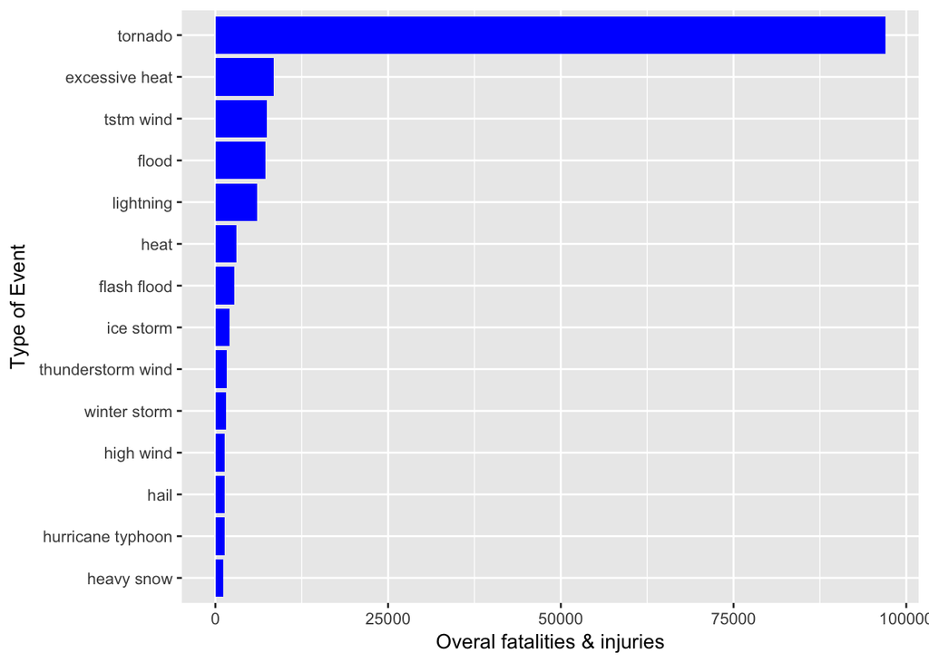

```r
## Filter most harmful datatable to events by having more than
## 1000 fatalities and injuries in total.
most_harmful <- most_harmful[TOTAL > 1000]

ggplot(data=most_harmful,
       aes(reorder(EVTYPE, TOTAL), TOTAL)) +
       geom_bar(stat="identity", fill = "blue") +
       coord_flip() +
       ylab("Overal fatalities & injuries") +
       xlab("Type of Event")
```

#### Economic impact

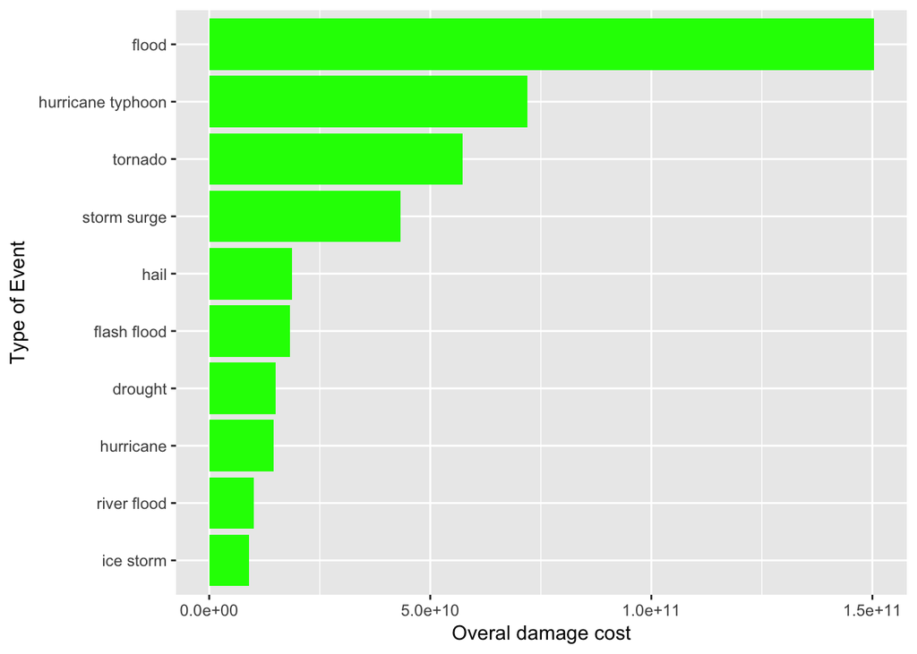

```r
## Filter total overal damage datatable to events to top 10 total damages
total_overal_damage <- total_overal_damage[order(-TOTAL_DAMAGE)]


ggplot(data=total_overal_damage[1:10],
       aes(reorder(EVTYPE, TOTAL_DAMAGE), TOTAL_DAMAGE)) +
       geom_bar(stat="identity", fill = "green") +
       coord_flip() +
       ylab("Overal damage cost") +
       xlab("Type of Event")
```

The given insight by this graph is that ** Flood** has most devastating type of event followed by **hurricane typhoon** and **tornado** in second and third place.